# Projeto Random Forest

Luan Santos

06/11/2021

# Introdução

Um novo modelo de *Credit Scoring* está sendo desenvolvido pela companhia X com o intuito de diminuir a quantidade de mau pagadores presentes em sua base de clientes. O objetivo é prever a variável BAD (ou seja, se o cliente é ou não inadimplente). Portanto, o presente documento irá demonstrar os passos que segui para desenvolvimento do modelo que preveja a variável BAD, passando por todos os aspectos de um projeto de Data Science.

# Limpeza, Tratamento e Manipulação de Dados

Pacotes que irei usar:

```r
library(Amelia)
library(caret)
library(ggplot2)
library(dplyr)
library(readr)
library(reshape)
library(randomForest)
library(e1071)
```

Foi fornecido base de dados dos clientes da companhia para execução do estudo de caso. Vejamos abaixo:

```r
(clientes <- read_csv("Clients.csv"))
```

| ...1 | clientId | shopId | gender | maritalStatus | age | numberOfDependents | education | flagResidencialPhone | areaCodeResidencialPhone | bestPaymentDay | shopRank | residenceType | monthsInResidence | flagMothersName | flagFathersName | flagResidenceTown_WorkingTown | flagResidenceState_WorkingState | monthsInTheJob | professionCode | mateIncome | flagResidencialAddress_PostalAddress | flagOtherCard | quantityBankingAccounts | flagMobilePhone | flagContactPhone | personalNetIncome | codeApplicationBooth | BAD |
| --- | --- | --- | --- | --- | --- | --- | --- | --- | --- | --- | --- | --- | --- | --- | --- | --- | --- | --- | --- | --- | --- | --- | --- | --- | --- | --- | --- | --- |
| 1 | 2 | 15 | F | S | 18 | 0 | NA | Y | 31 | 20 | 0 | P | 216 | Y | Y | Y | Y | 12 | 853 | 0 | Y | N | 0 | N | N | 300.00 | 0 | 0 |
| 2 | 4 | 12 | F | C | 47 | 0 | NA | N | 31 | 25 | 0 | P | 180 | Y | Y | N | Y | 24 | 35 | 0 | Y | N | 0 | N | N | 304.00 | 0 | 0 |
| 3 | 5 | 16 | F | S | 28 | 0 | NA | Y | 31 | 25 | 0 | O | 12 | Y | Y | Y | Y | 12 | 24 | 0 | Y | N | 0 | N | N | 250.00 | 0 | 0 |
| 4 | 6 | 24 | M | S | 26 | 0 | NA | N | 31 | 28 | 0 | P | 180 | Y | Y | N | Y | 0 | 999 | 0 | Y | N | 0 | N | N | 800.00 | 0 | 0 |
| 5 | 7 | 55 | F | S | 22 | 0 | NA | Y | 31 | 12 | 0 | A | 0 | Y | Y | Y | Y | 48 | 999 | 0 | Y | N | 0 | N | N | 410.00 | 0 | 0 |
| 6 | 8 | 6 | F | C | 21 | 0 | NA | Y | 23 | 28 | 0 | A | 24 | Y | Y | Y | Y | 12 | 40 | 800 | Y | N | 0 | N | N | 248.00 | 0 | 0 |
| 7 | 9 | 3 | F | S | 27 | 0 | NA | Y | 31 | 20 | 0 | A | 0 | Y | Y | Y | Y | 0 | 950 | 0 | Y | N | 0 | N | N | 1000.00 | 0 | 1 |
| 8 | 10 | 23 | F | C | 57 | 0 | NA | Y | 31 | 12 | 0 | P | 24 | Y | Y | N | Y | 96 | 13 | 0 | Y | N | 0 | N | N | 856.00 | 0 | 0 |
| 9 | 11 | 25 | F | S | 53 | 0 | NA | Y | 31 | 18 | 0 | P | 60 | Y | Y | N | Y | 24 | 13 | 0 | Y | N | 0 | N | N | 738.00 | 0 | 1 |
| 10 | 12 | 12 | F | C | 32 | 0 | NA | Y | 31 | 12 | 0 | P | 24 | Y | Y | N | Y | 0 | 165 | 0 | Y | N | 0 | N | N | 700.00 | 0 | 0 |

[output cut: 9990 more lines]

Analisando a estrutura da base de dados:

```r
str(clientes, give.attr = F)
```

```
## spc_tbl_ [40,000 × 29] (S3: spec_tbl_df/tbl_df/tbl/data.frame)
##  $ ...1                                : num [1:40000] 1 2 3 4 5 6 7 8 9 10 ...
##  $ clientId                            : num [1:40000] 2 4 5 6 7 8 9 10 11 12 ...
##  $ shopId                              : num [1:40000] 15 12 16 24 55 6 3 23 25 12 ...
##  $ gender                              : chr [1:40000] "F" "F" "F" "M" ...
##  $ maritalStatus                       : chr [1:40000] "S" "C" "S" "S" ...
##  $ age                                 : num [1:40000] 18 47 28 26 22 21 27 57 53 32 ...
##  $ numberOfDependents                  : num [1:40000] 0 0 0 0 0 0 0 0 0 0 ...
##  $ education                           : logi [1:40000] NA NA NA NA NA NA ...
##  $ flagResidencialPhone                : chr [1:40000] "Y" "N" "Y" "N" ...
##  $ areaCodeResidencialPhone            : num [1:40000] 31 31 31 31 31 23 31 31 31 31 ...
##  $ bestPaymentDay                      : num [1:40000] 20 25 25 28 12 28 20 12 18 12 ...
##  $ shopRank                            : num [1:40000] 0 0 0 0 0 0 0 0 0 0 ...
##  $ residenceType                       : chr [1:40000] "P" "P" "O" "P" ...
##  $ monthsInResidence                   : num [1:40000] 216 180 12 180 0 24 0 24 60 24 ...
##  $ flagMothersName                     : chr [1:40000] "Y" "Y" "Y" "Y" ...
##  $ flagFathersName                     : chr [1:40000] "Y" "Y" "Y" "Y" ...
##  $ flagResidenceTown_WorkingTown       : chr [1:40000] "Y" "N" "Y" "N" ...
##  $ flagResidenceState_WorkingState     : chr [1:40000] "Y" "Y" "Y" "Y" ...
##  $ monthsInTheJob                      : num [1:40000] 12 24 12 0 48 12 0 96 24 0 ...
##  $ professionCode                      : num [1:40000] 853 35 24 999 999 40 950 13 13 165 ...
##  $ mateIncome                          : num [1:40000] 0 0 0 0 0 800 0 0 0 0 ...
##  $ flagResidencialAddress_PostalAddress: chr [1:40000] "Y" "Y" "Y" "Y" ...
##  $ flagOtherCard                       : chr [1:40000] "N" "N" "N" "N" ...
##  $ quantityBankingAccounts             : num [1:40000] 0 0 0 0 0 0 0 0 0 0 ...
##  $ flagMobilePhone                     : chr [1:40000] "N" "N" "N" "N" ...
##  $ flagContactPhone                    : chr [1:40000] "N" "N" "N" "N" ...
##  $ personalNetIncome                   : num [1:40000] 300 304 250 800 410 248 1000 856 738 700 ...
##  $ codeApplicationBooth                : num [1:40000] 0 0 0 0 0 0 0 0 0 0 ...
##  $ BAD                                 : num [1:40000] 0 0 0 0 0 0 1 0 1 0 ...
```

### Verificando valores ausentes e os removendo do dataset

Para visualizar valores ausentes:

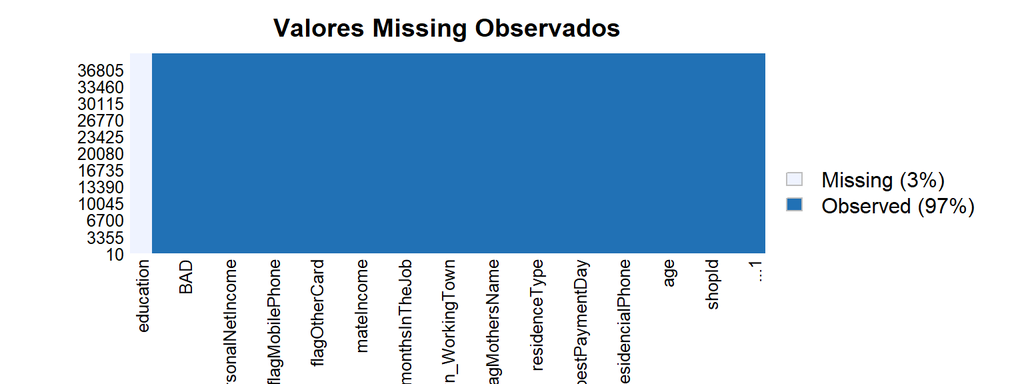

```r
missmap(clientes, main = "Valores Missing Observados")
```

Contagem de valores ausentes

```r
sapply(clientes, function(x) sum(is.na(x)))
```

```
##                                 ...1                             clientId
##                                    0                                    0
##                               shopId                               gender
##                                    0                                    3
##                        maritalStatus                                  age
##                                    0                                    0
##                   numberOfDependents                            education
##                                    0                                40000
##                 flagResidencialPhone             areaCodeResidencialPhone
##                                    0                                    0
##                       bestPaymentDay                             shopRank
##                                    0                                    0
##                        residenceType                    monthsInResidence
##                                    0                                    0
##                      flagMothersName                      flagFathersName
##                                    0                                    0
##        flagResidenceTown_WorkingTown      flagResidenceState_WorkingState
##                                    0                                    0
##                       monthsInTheJob                       professionCode
##                                    0                                    0
##                           mateIncome flagResidencialAddress_PostalAddress
##                                    0                                    0
##                        flagOtherCard              quantityBankingAccounts
##                                    0                                    0
##                      flagMobilePhone                     flagContactPhone
##                                    0                                    0
##                    personalNetIncome                 codeApplicationBooth
##                                    0                                    0
##                                  BAD
##                                    0
```

```r
clientes <- clientes %>%
  mutate(...1 = NULL, education = NULL) %>%
  tidyr::drop_na()

str(clientes, give.attr = F)
```

```
## tibble [39,997 × 27] (S3: tbl_df/tbl/data.frame)
##  $ clientId                            : num [1:39997] 2 4 5 6 7 8 9 10 11 12 ...
##  $ shopId                              : num [1:39997] 15 12 16 24 55 6 3 23 25 12 ...
##  $ gender                              : chr [1:39997] "F" "F" "F" "M" ...
##  $ maritalStatus                       : chr [1:39997] "S" "C" "S" "S" ...
##  $ age                                 : num [1:39997] 18 47 28 26 22 21 27 57 53 32 ...
##  $ numberOfDependents                  : num [1:39997] 0 0 0 0 0 0 0 0 0 0 ...
##  $ flagResidencialPhone                : chr [1:39997] "Y" "N" "Y" "N" ...
##  $ areaCodeResidencialPhone            : num [1:39997] 31 31 31 31 31 23 31 31 31 31 ...
##  $ bestPaymentDay                      : num [1:39997] 20 25 25 28 12 28 20 12 18 12 ...
##  $ shopRank                            : num [1:39997] 0 0 0 0 0 0 0 0 0 0 ...
##  $ residenceType                       : chr [1:39997] "P" "P" "O" "P" ...
##  $ monthsInResidence                   : num [1:39997] 216 180 12 180 0 24 0 24 60 24 ...
##  $ flagMothersName                     : chr [1:39997] "Y" "Y" "Y" "Y" ...
##  $ flagFathersName                     : chr [1:39997] "Y" "Y" "Y" "Y" ...
##  $ flagResidenceTown_WorkingTown       : chr [1:39997] "Y" "N" "Y" "N" ...
##  $ flagResidenceState_WorkingState     : chr [1:39997] "Y" "Y" "Y" "Y" ...
##  $ monthsInTheJob                      : num [1:39997] 12 24 12 0 48 12 0 96 24 0 ...
##  $ professionCode                      : num [1:39997] 853 35 24 999 999 40 950 13 13 165 ...
##  $ mateIncome                          : num [1:39997] 0 0 0 0 0 800 0 0 0 0 ...
##  $ flagResidencialAddress_PostalAddress: chr [1:39997] "Y" "Y" "Y" "Y" ...
##  $ flagOtherCard                       : chr [1:39997] "N" "N" "N" "N" ...
##  $ quantityBankingAccounts             : num [1:39997] 0 0 0 0 0 0 0 0 0 0 ...
##  $ flagMobilePhone                     : chr [1:39997] "N" "N" "N" "N" ...
##  $ flagContactPhone                    : chr [1:39997] "N" "N" "N" "N" ...
##  $ personalNetIncome                   : num [1:39997] 300 304 250 800 410 248 1000 856 738 700 ...
##  $ codeApplicationBooth                : num [1:39997] 0 0 0 0 0 0 0 0 0 0 ...
##  $ BAD                                 : num [1:39997] 0 0 0 0 0 0 1 0 1 0 ...
```

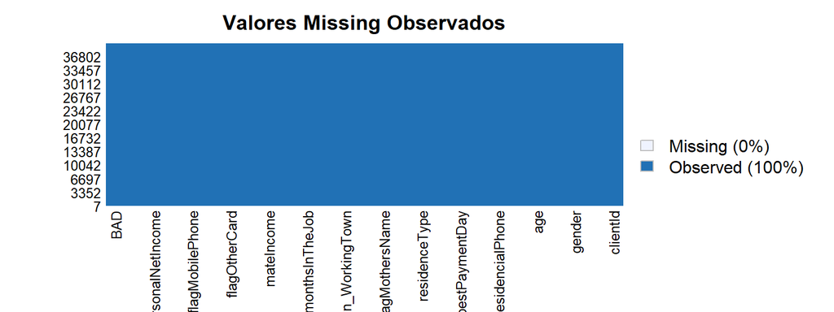

```r
missmap(clientes, main = "Valores Missing Observados")
```

# Análise Exploratória

Agora com a base de dados limpa, posso começar a explorar sua composição. Primeiro irei transformar a variável dependente para o tipo fator:

```r
class(clientes$BAD)
```

```
## [1] "numeric"
```

```r
clientes$BAD <- as.factor(clientes$BAD)
class(clientes$BAD)
```

```
## [1] "factor"
```

Agora verei o total de adimplentes vs inadimplentes:

```r
table(clientes$BAD)
```

```
##
##     0     1
## 32098  7899
```

Em porcentagens:

```r
prop.table(table(clientes$BAD))
```

```
##
##         0         1
## 0.8025102 0.1974898
```

Plot da distribuição

[figure not shown]

```r
clientes %>%
  ggplot(aes(x = BAD, y = length(BAD))) +
  geom_bar(stat = "identity") +
  labs(x = "BAD", y = "Quantidade") +
  theme_bw()
```

# Manipulação de dados

```r
set.seed(1234)
```

### Amostragem Estratificada

Selecionando as linhas de acordo com a variável BAD como strata. Irei separar 75% da base em treino e 25% em teste.

```r
indice <- createDataPartition(clientes$BAD, p = 0.75, list = F)
dim(indice)
```

```
## [1] 29999     1
```

Definindo os dados de treinamento para o modelo de ML. Definindo como subconjunto da base de dados original através dos números índices de linha

```r
dados_treino <- clientes[indice,]
dim(dados_treino)
```

```
## [1] 29999    27
```

```r
table(dados_treino$BAD)
```

```
##
##     0     1
## 24074  5925
```

```r
prop.table(table(dados_treino$BAD))
```

```
##
##         0         1
## 0.8024934 0.1975066
```

Comparando a base de treino e original

```r
compare <- cbind(Treinamento = prop.table(table(dados_treino$BAD)),
                 Original = prop.table(table(clientes$BAD)))

melt_compare <- melt(compare)
```

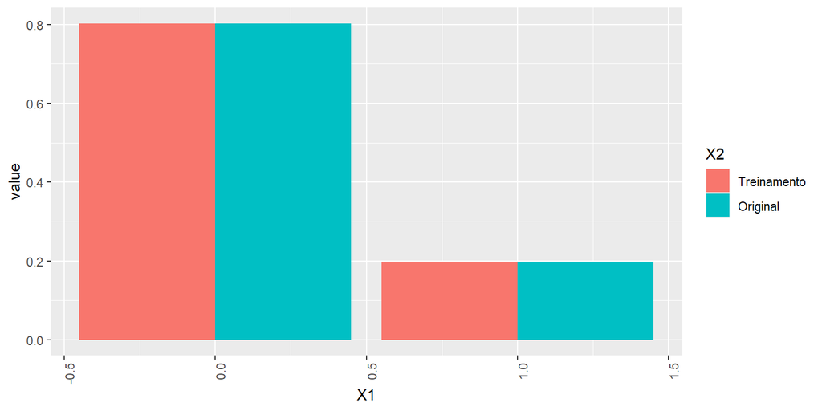

```r
melt_compare %>%
  ggplot(aes(x = X1, y = value)) +
  geom_bar(aes(fill = X2), stat = "identity", position = "dodge") +
  theme(axis.text.x = element_text(angle = 90, hjust = 1))
```

Definindo os dados de teste

```r
dados_teste <- clientes[-indice,]
dim(dados_teste)
```

```
## [1] 9998   27
```

# Modelo de Machine Learning - Random Forest

Utilizarei o conhecido algoritmo de **Random Forest** para treinar o modelo e então testá-lo nos dados para teste. Nesse primeiro momento utilizarei todas as variáveis com 100 árvores para ver o comportamento do modelo frente as variáveis da base de dados.

```r
(modelo_v1 <- randomForest(BAD ~ ., data = dados_treino, ntree = 100))
```

```
##
## Call:
##  randomForest(formula = BAD ~ ., data = dados_treino, ntree = 100)
##                Type of random forest: classification
##                      Number of trees: 100
## No. of variables tried at each split: 5
##
##         OOB estimate of  error rate: 19.94%
## Confusion matrix:
##       0   1 class.error
## 0 23824 250  0.01038465
## 1  5731 194  0.96725738
```

Sendo a estimativa de erro OOB como uma medida de erro sintética dos dados, podemos ver que modelo obteve uma taxa de erro de 19% inicialmente. Ao plotar o modelo (veja abaixo) vemos como ele começa errando bastante até se ajustar aos dados.

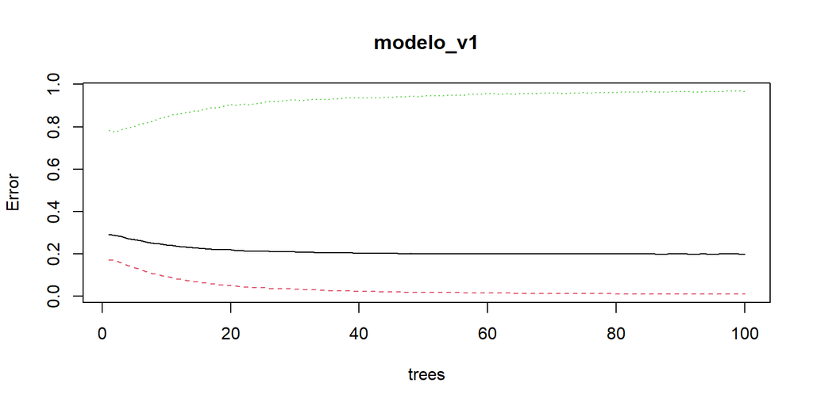

```r
plot(modelo_v1)
```

Efetuando as previsões com os dados de teste:

```r
previsoes_v1 <- predict(modelo_v1, dados_teste)
```

### Matriz de confusão (*confusion matrix*)

```r
(cm_v1 <- caret::confusionMatrix(previsoes_v1, dados_teste$BAD, positive = "1"))
```

```
## Confusion Matrix and Statistics
##
##           Reference
## Prediction    0    1
##          0 7985 1915
##          1   39   59
##
##                Accuracy : 0.8046
##                  95% CI : (0.7966, 0.8123)
##     No Information Rate : 0.8026
##     P-Value [Acc > NIR] : 0.3128
##
##                   Kappa : 0.039
##
##  Mcnemar's Test P-Value : <2e-16
##
##             Sensitivity : 0.029889
##             Specificity : 0.995140
##          Pos Pred Value : 0.602041
##          Neg Pred Value : 0.806566
##              Prevalence : 0.197439
##          Detection Rate : 0.005901
##    Detection Prevalence : 0.009802
##       Balanced Accuracy : 0.512514
##
##        'Positive' Class : 1
##
```

Vemos como a *Accuracy* do modelo se mostrou bem alta, com valor acima de 80%.

Agora vamos calcular outras métricas para avaliação do modelo, tais como *Precision*, *Recall* e *F1*. Primeiro vemos o valor do **Precision**, sendo ele uma boa métrica para saber a acurácia/precisão do modelo em relação aos valores previstos como positivos e o quanto realmente deles são positivos:

```r
(precision <- posPredValue(previsoes_v1, dados_teste$BAD))
```

```
## [1] 0.8065657
```

Agora calcularei o **Recall**, que é uma métrica calculada a partir da quantidade de Positivos Verdadeiros sobre o total de Positivos Reais da base. Isto é, essa métrica é feita para capturar quantos do total de Positivos, o modelo rotula como verdadeiro.

```r
(recall <- sensitivity(previsoes_v1, dados_teste$BAD))
```

```
## [1] 0.9951396
```

Para avaliação desses indicadores, é importanto vermos o problema real a ser resolvido com o modelo. Em outras palavras, é preciso observar a necessidade que ira ser preenchida pelo modelo. Para casos onde é dado peso maior aos Positivos Verdadeiros, deve-se olhar para a Precision. Ou seja, quanto o modelo classifica como Positivo Verdadeiro do total de predições Positivas.

Por outro lado, para casos que se quer aumentar os True Positivos frente aos False Negative, deve-se olhar para o Recall. No nosso caso, a melhor métrica a ser selecionada seria o Recall, visto que queremos descobrir se um cliente será adimplente ou inadimplente. Ou seja, existe um custo maior associado ao classificar falsos negativos (clientes inadimplentes) visto que o objetivo do modelo é diminuir a inadimplencia e classificar melhor os clientes.

Agora olhemos para a métrica F1-Score, que é um indicador que procura um balanceamento entre as duas métricas anteriores. Além disso, também é ideal para dados com distribuição desigual de classes (grande quantidade de negativos reais - nesse caso, adimplentes).

```r
(F1 <- 2 * ((precision * recall) / (precision + recall)))
```

```
## [1] 0.8909842
```

A seguir tentarei melhorar o modelo usando algumas técnicas.

# Técnicas para melhoria do modelo

### Balanceamento de Classe - Undersamplinp

Primeiro, irei dividir a base de treino em 50/50 buscando balancear as classes.

```r
table(dados_treino$BAD)
```

```
##
##     0     1
## 24074  5925
```

```r
dados_balanceado <- dados_treino %>%
  group_by(BAD) %>%
  sample_n(table(dados_treino$BAD)[[2]]) %>%
  ungroup()

table(dados_balanceado$BAD)
```

```
##
##    0    1
## 5925 5925
```

### Testando o modelo balanceado

```r
(modelo_v2 <- randomForest(BAD ~ ., data = dados_balanceado, ntree = 100))
```

```
##
## Call:
##  randomForest(formula = BAD ~ ., data = dados_balanceado, ntree = 100)
##                Type of random forest: classification
##                      Number of trees: 100
## No. of variables tried at each split: 5
##
##         OOB estimate of  error rate: 39.34%
## Confusion matrix:
##      0    1 class.error
## 0 3582 2343   0.3954430
## 1 2319 3606   0.3913924
```

Neste primeiro momento, vemos como a taxa de erro OOB subiu expressivamente, ficando acima dos 39%. Abaixo também vemos como o erro começa bem alto até se estabilizar nessa faixa.

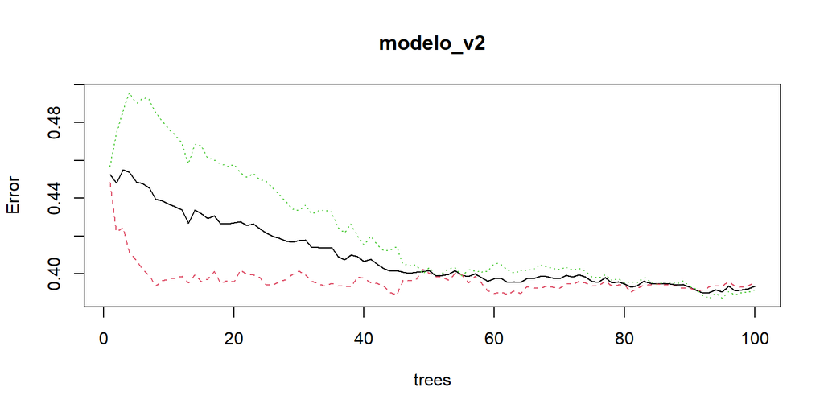

```r
plot(modelo_v2)
```

Previsões e **confusion matrix**

```r
previsoes_v2 <- predict(modelo_v2, dados_teste)

(cm_v2 <- caret::confusionMatrix(previsoes_v2, dados_teste$BAD, positive = "1"))
```

```
## Confusion Matrix and Statistics
##
##           Reference
## Prediction    0    1
##          0 4968  761
##          1 3056 1213
##
##                Accuracy : 0.6182
##                  95% CI : (0.6086, 0.6278)
##     No Information Rate : 0.8026
##     P-Value [Acc > NIR] : 1
##
##                   Kappa : 0.1624
##
##  Mcnemar's Test P-Value : <2e-16
##
##             Sensitivity : 0.6145
##             Specificity : 0.6191
##          Pos Pred Value : 0.2841
##          Neg Pred Value : 0.8672
##              Prevalence : 0.1974
##          Detection Rate : 0.1213
##    Detection Prevalence : 0.4270
##       Balanced Accuracy : 0.6168
##
##        'Positive' Class : 1
##
```

É possível notar também uma queda expressiva para a **Accuracy**, ficando no patamar de 0.61. Isso acontece possivelmente pois os dados estão menos viesados (base equilibrada entre adimplente e inadimplente).

Agora olhemos para as demais métricas:

```r
(precision <- posPredValue(previsoes_v2, dados_teste$BAD))
```

```
## [1] 0.867167
```

```r
(recall <- sensitivity(previsoes_v2, dados_teste$BAD))
```

```
## [1] 0.6191426
```

```r
(F1 <- 2 * ((precision * recall) / (precision + recall)))
```

```
## [1] 0.7224606
```

Os indicadores Recall e F1-Score também diminuiram bastante dos vistos anteriormente, entretanto esses indicam melhor a realidade dos dados.

## Importância das variáveis

Avaliando a importância das variáveis preditoras para as previsões. Para isso irei obter a importância (peso relativo dado pelo algoritmo para criar o modelo) para as variáveis e criando ranking de variáveis baseado nesse indicador:

```r
imp_var <- importance(modelo_v2)
varImportance <- data.frame(Variables = row.names(imp_var),
                            Importance = round(imp_var[, 'MeanDecreaseGini'], 2))

(rankImportance <- varImportance %>%
  mutate(Rank = paste0('#', dense_rank(desc(Importance)))))
```

|  | Variables | Importance | Rank |
| --- | --- | --- | --- |
| clientId | clientId | 713.11 | #1 |
| shopId | shopId | 469.47 | #6 |
| gender | gender | 102.89 | #12 |
| maritalStatus | maritalStatus | 183.15 | #9 |
| age | age | 672.06 | #2 |
| numberOfDependents | numberOfDependents | 0.00 | #21 |
| flagResidencialPhone | flagResidencialPhone | 95.16 | #14 |
| areaCodeResidencialPhone | areaCodeResidencialPhone | 148.73 | #11 |
| bestPaymentDay | bestPaymentDay | 367.51 | #8 |
| shopRank | shopRank | 12.61 | #19 |

[output cut: 16 more lines]

Visualizando a importancia relativa das variáveis

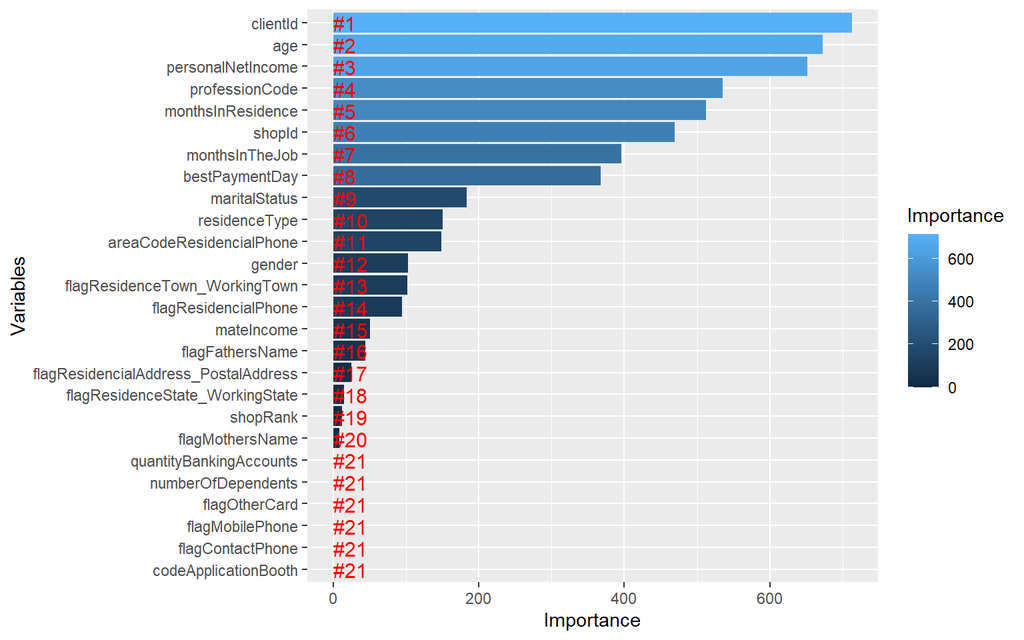

```r
rankImportance %>%
  ggplot(aes(x = reorder(Variables, Importance),
             y = Importance,
             fill = Importance)) +
  geom_bar(stat = 'identity') +
  geom_text(aes(x = Variables, y = 0.5, label = Rank),
            hjust = 0,
            vjust = 0.55,
            size = 4,
            colour = 'red') +
  labs(x = 'Variables') +
  coord_flip()
```

Vemos como o modelo deu grande importância para as variáveis **ClientID** e **ShopID** mesmo não fazendo sentido em sua previsão (não possuem informação relevante para a previsão). O motivo seria, possivelmente, que essas variáveis representam cada cliente da base contém todas as informações a cerca dele.

### Criando uma versão 3 do modelo

Agora com a base de dados balanceada e variáveis mais relevantes para a predição, irei criar uma 3ª versão do modelo. Irei usar somente as variáveis relevantes para o modelo, de acordo com a sua *Importance*.

```r
(modelo_v3 <- randomForest(BAD ~
                            age + personalNetIncome + professionCode +
                            monthsInResidence + monthsInTheJob + bestPaymentDay,
                          data = dados_balanceado,
                          ntree = 100))
```

```
##
## Call:
##  randomForest(formula = BAD ~ age + personalNetIncome + professionCode +      monthsInResidence + monthsInTheJob + bestPaymentDay, data = dados_balanceado,      ntree = 100)
##                Type of random forest: classification
##                      Number of trees: 100
## No. of variables tried at each split: 2
##
##         OOB estimate of  error rate: 41.83%
## Confusion matrix:
##      0    1 class.error
## 0 3420 2505   0.4227848
## 1 2452 3473   0.4138397
```

Em sua 3ª versão, vemos como o erro OOB se elevou novamente, indo para o patamar de 42%.

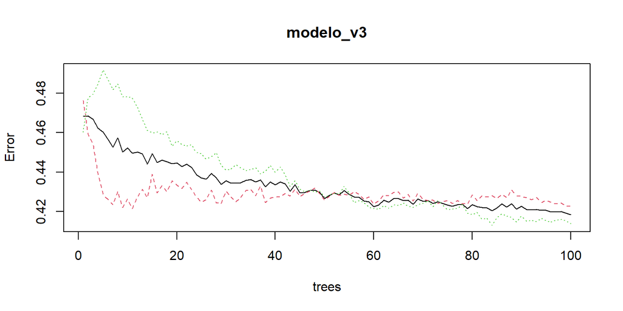

```r
plot(modelo_v3)
```

**Previsão e Confussion Matrix**

```r
previsoes_v3 <- predict(modelo_v3, dados_teste)

(cm_v3 <- confusionMatrix(previsoes_v3, dados_teste$BAD, positive = "1"))
```

```
## Confusion Matrix and Statistics
##
##           Reference
## Prediction    0    1
##          0 4590  822
##          1 3434 1152
##
##                Accuracy : 0.5743
##                  95% CI : (0.5646, 0.584)
##     No Information Rate : 0.8026
##     P-Value [Acc > NIR] : 1
##
##                   Kappa : 0.1038
##
##  Mcnemar's Test P-Value : <2e-16
##
##             Sensitivity : 0.5836
##             Specificity : 0.5720
##          Pos Pred Value : 0.2512
##          Neg Pred Value : 0.8481
##              Prevalence : 0.1974
##          Detection Rate : 0.1152
##    Detection Prevalence : 0.4587
##       Balanced Accuracy : 0.5778
##
##        'Positive' Class : 1
##
```

O mesmo ocorre para a Accuracy, caindo para o patamar de 0.58, medida baixa comparada a sua primeira versão. Agora veremos as demais métricas.

```r
(precision <- posPredValue(previsoes_v3, dados_teste$BAD))
```

```
## [1] 0.8481153
```

```r
(recall <- sensitivity(previsoes_v3, dados_teste$BAD))
```

```
## [1] 0.5720339
```

```r
(F1 <- 2 * ((precision * recall) / (precision + recall)))
```

```
## [1] 0.6832391
```

O comportamento para as demais métricas foram semelhantes, caindo para patamares menores do que os vistos antes.

Por fim, o modelo em sua 3ª versão obteve resultados expressivamentes menores do que os vistos no começo, entretanto eles correspondem melhor a realidade do problema e da realidade da base de dados. Isto é, mesmo obtendo resultados “piores”, ele está melhor ajustado, balanceado e compreende melhor a realidade, sendo assim possível chama-lo de um modelo “melhor”.